# Stones2Milestones Path Analysis Project: Understanding the Users and their Interactions with the App

We next compare the type of story short/long-term users choose first on their first day on the app in the figure below.

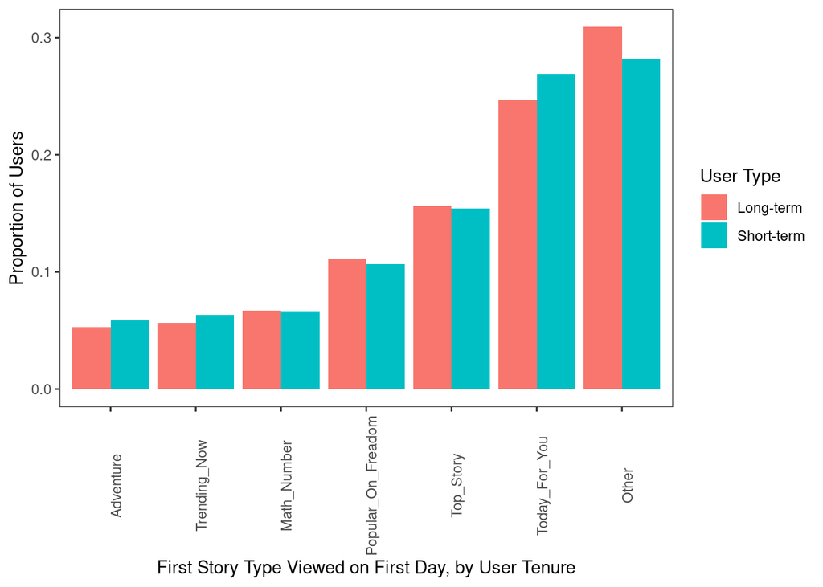

```r
# Get most popular type of story for tenured users in their first day of using the app
tenured_users_daily_compo_story_types <- tenured_users_compo %>%
  dplyr::filter(days_since_signup == 0)   %>%
  select(child_id, section_id, story_started_ts) %>%
  group_by(child_id)

# Sort users-story interactions by the interaction time stamp and get the first interaction for each user in their first daily session
tenured_users_daily_compo_first_story_type <- tenured_users_daily_compo_story_types[order(as.Date(tenured_users_daily_compo_story_types$story_started_ts), tenured_users_daily_compo_story_types$child_id),] %>% group_by(child_id) %>% dplyr::filter(row_number()==1)

# Count number of users who watched the same story type as their first story in their first daily session
tenured_users_daily_compo_first_story_type <- tenured_users_daily_compo_first_story_type  %>% group_by(section_id) %>% summarize(num_users = n())

# Get proportion of each story type for tenured users
tenured_users_daily_compo_first_story_type$prop = (tenured_users_daily_compo_first_story_type$num_users /
                                                sum(tenured_users_daily_compo_first_story_type$num_users))

# Add a tenured user_type column for easier plotting
tenured_users_daily_compo_first_story_type$user_type <- 'Long-term'

# Get the top 6 story types watched first in the first daily session
top_six_stories_tenured <- tenured_users_daily_compo_first_story_type %>%
  arrange(desc(num_users)) %>%
  head(6)

# Get the sum of view counts of all other story types and put it in the `OTHER` bin
other_story_types_tenured <- tenured_users_daily_compo_first_story_type %>%
  arrange(desc(num_users)) %>%
  dplyr::filter(!(section_id %in% top_six_stories_tenured$section_id)) %>%
  select(num_users,prop) %>%
  summarize(num_users = sum(num_users),
            prop =sum(prop))

# Add row to df with top 6 story types as well as all other story types bucketed into the `OTHER` bin
top_six_story_types_tenured <- top_six_stories_tenured %>%
  add_row(section_id = "Other",
          num_users = other_story_types_tenured$num_users,
          prop = other_story_types_tenured$prop,
          user_type = "Long-term")

# Get most popular type of story for short-term users in their first day of using the app
short_term_users_daily_compo_story_types <- short_term_users_compo %>%
  dplyr::filter(days_since_signup == 0)   %>%
  select(child_id, section_id, story_started_ts) %>%
  group_by(child_id)

# Sort users-story interactions by the interaction time stamp and get the first interaction for each user in their first daily session
short_term_users_daily_compo_first_story_type <- short_term_users_daily_compo_story_types[order(as.Date(short_term_users_daily_compo_story_types$story_started_ts), short_term_users_daily_compo_story_types$child_id),] %>% group_by(child_id) %>% dplyr::filter(row_number()==1)

# Count number of users who watched the same story type as their first story in their first daily session
short_term_users_daily_compo_first_story_type <- short_term_users_daily_compo_first_story_type  %>% group_by(section_id) %>% summarize(num_users = n())

# Get proportion of each story type for short-term users
short_term_users_daily_compo_first_story_type$prop = (short_term_users_daily_compo_first_story_type$num_users /
                                                sum(short_term_users_daily_compo_first_story_type$num_users))

# Add a short_term user_type column for easier plotting
short_term_users_daily_compo_first_story_type$user_type <- 'Short-term'

# Get the top 6 story types in first daily session for short-term users
top_six_story_types_short_term <- short_term_users_daily_compo_first_story_type %>%
  arrange(desc(num_users)) %>%
  head(6)

# Get the sum of view counts of all other story types and put it in the `OTHER` bin
other_story_types_short_term <- short_term_users_daily_compo_first_story_type %>%
  arrange(desc(num_users)) %>%
  dplyr::filter(!(section_id %in% top_six_story_types_short_term$section_id)) %>%
  select(num_users,prop) %>%
  summarize(num_users = sum(num_users),
            prop =sum(prop))

# Add row to df with top 6 story types as well as all other story types bucketed into the `OTHER` bin
top_six_story_types_short_term <- top_six_story_types_short_term %>%
  add_row(section_id = "Other",
          num_users = other_story_types_short_term$num_users,
          prop = other_story_types_short_term$prop,
          user_type = "Short-term")

# Combine the two dataframes together for easier plotting
top_six_story_types_all <- rbind(top_six_story_types_short_term,
                                 top_six_story_types_tenured)

# Plot proportion of short- and long-term users by story type
ggplot(data = top_six_story_types_all,
       aes(fct_reorder(section_id, prop),prop)) +
  geom_bar(stat="identity",
           aes(fill = user_type),
           position=position_dodge()) +
  xlab("First Story Type Viewed on First Day, by User Tenure") +
  ylab("Proportion of Users") +
  labs(fill = "User Type") +
  theme_bw() +
  theme(axis.text.x=element_text(angle = 90, hjust=0.5),
        panel.grid.major = element_blank(),
        panel.grid.minor = element_blank())
```

Each bar in the graph shows the number of short/long-term users whose first story on their first day of usage was its respective type. Again, the figure shows only the top six story types, with the rest grouped into the “Other” category. The figure shows few differences in the choice of first story to view on the first day for short- and long-term users.

Lastly, we compare the app section from which short/long-term users choose their first story on their first day in the figure below.

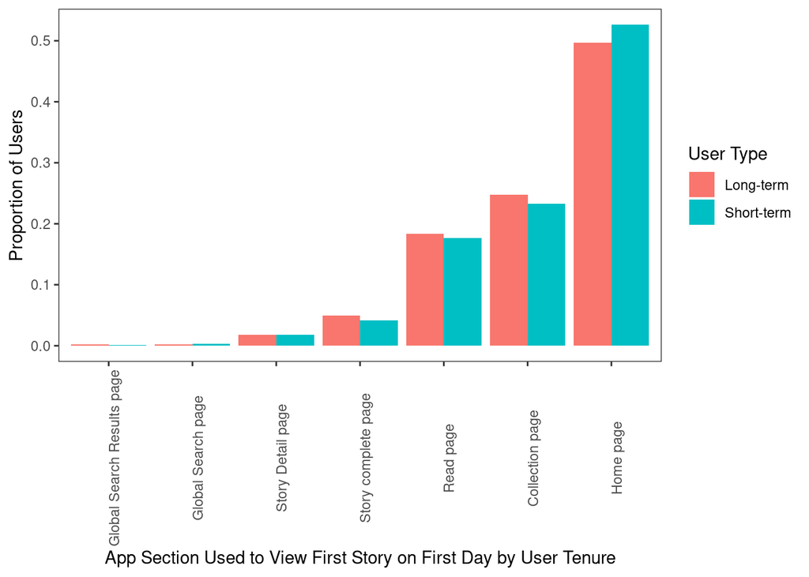

```r
# Get most popular type of app feature for tenured users in their first day of using the app
tenured_users_daily_compo_app_feature_types <- tenured_users_compo %>%
  dplyr::filter(days_since_signup == 0)   %>%
  select(child_id, source_page_id, story_started_ts) %>%
  group_by(child_id)

# Sort users-story interactions by the interaction time stamp and get the first interaction for each user in their first daily session
tenured_users_daily_compo_first_app_feature_type <- tenured_users_daily_compo_app_feature_types[order(as.Date(tenured_users_daily_compo_app_feature_types$story_started_ts), tenured_users_daily_compo_app_feature_types$child_id),] %>% group_by(child_id) %>% dplyr::filter(row_number()==1)

# Count number of users who used the same app feature to watch their first story in their first daily session
tenured_users_daily_compo_first_app_feature_type <- tenured_users_daily_compo_first_app_feature_type  %>% group_by(source_page_id) %>% summarize(num_users = n())

# Get proportion of each story type for tenured users
tenured_users_daily_compo_first_app_feature_type$prop = (tenured_users_daily_compo_first_app_feature_type$num_users /
                                                sum(tenured_users_daily_compo_first_app_feature_type$num_users))

# Add a tenured user_type column for easier plotting
tenured_users_daily_compo_first_app_feature_type$user_type <- 'Long-term'

# Get most popular type of story for short-term users in their first day of using the app
short_term_users_daily_compo_app_feature_types <- short_term_users_compo %>%
  dplyr::filter(days_since_signup == 0)   %>%
  select(child_id, source_page_id, story_started_ts) %>%
  group_by(child_id)

# Sort users-story interactions by the interaction time stamp and get the first interaction for each user in their first daily session
short_term_users_daily_compo_first_app_feature_type <- short_term_users_daily_compo_app_feature_types[order(as.Date(short_term_users_daily_compo_app_feature_types$story_started_ts), short_term_users_daily_compo_app_feature_types$child_id),] %>% group_by(child_id) %>% dplyr::filter(row_number()==1)

# Count number of users who watched the same story type as their first story in their first daily session
short_term_users_daily_compo_first_app_feature_type <- short_term_users_daily_compo_first_app_feature_type  %>% group_by(source_page_id) %>% summarize(num_users = n())

# Get proportion of each story type for short-term users
short_term_users_daily_compo_first_app_feature_type$prop = (short_term_users_daily_compo_first_app_feature_type$num_users /
                                                sum(short_term_users_daily_compo_first_app_feature_type$num_users))

# Add a short_term user_type column for easier plotting
short_term_users_daily_compo_first_app_feature_type$user_type <- 'Short-term'

# Combine the two dataframes together for easier plotting
app_feature_types_all <- rbind(short_term_users_daily_compo_first_app_feature_type,
                                 tenured_users_daily_compo_first_app_feature_type)

# Plot proportion of short- and long-term users by story type
ggplot(data = app_feature_types_all,
       aes(fct_reorder(source_page_id, prop),prop)) +
  geom_bar(stat="identity",
           aes(fill = user_type),
           position=position_dodge()) +
  xlab("App Section Used to View First Story on First Day by User Tenure") +
  ylab("Proportion of Users") +
  labs(fill = "User Type") +
  theme_bw() +
  theme(axis.text.x=element_text(angle = 90, hjust=0.5),
        panel.grid.major = element_blank(),
        panel.grid.minor = element_blank())
```

Each bar in the graph shows the number of short/long-term users whose first story on their first day was found through its respective app section. The figure shows that, again, there are few differences in short- and long-term users in this initial choice.

### First Two Weeks

Lastly, we compare the first two weeks of app usage for short- versus long-term users. We must again restrict the sample to users who show some activity at least two weeks after sign-up.

We begin by comparing the number of stories viewed in the first two weeks of app usage for short- and long-term users in the figure below.

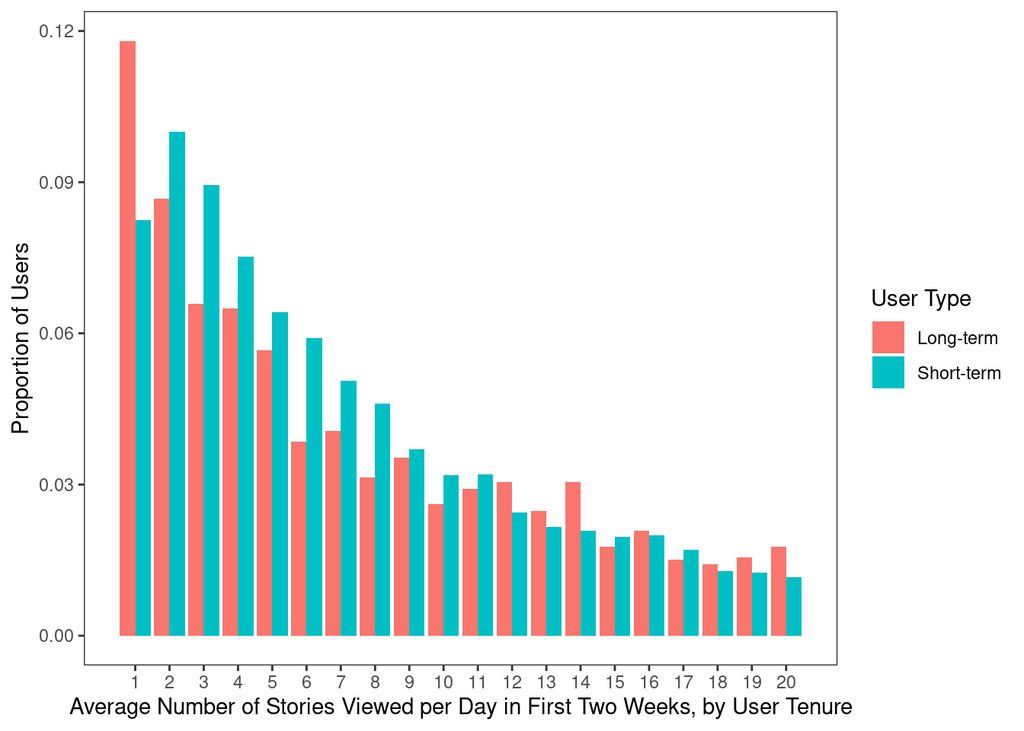

```r
tenured_users_compo_first_two_weeks_stories <- tenured_users_compo %>%
  dplyr::filter(days_since_signup < 14) %>%
  group_by(child_id) %>%
  summarize(n_stories_viewed = n_distinct(view_id)) %>%
  group_by(n_stories_viewed) %>%
  summarize(n_users = n())

new_users_compo_first_weekly_stories <- new_users_weekly_compo %>%
  select(child_id, days_since_signup, story_id) %>%
  group_by(child_id, days_since_signup) %>%
  summarize(n_stories = n()) %>%
  group_by(child_id) %>%
  summarize(n_stories = mean(n_stories))

# Put tenured users with more than 20 stories watched in the first session in the same bin
tenured_users_compo_first_two_weeks_stories$n_stories_viewed[tenured_users_compo_first_two_weeks_stories$n_stories_viewed> 20] <- 20

# Add a tenure user.type column which will serve as a label when plotting graphs
tenured_users_compo_first_two_weeks_stories$user.type <- 'Long-term'

short_term_users_compo_first_two_weeks_stories <- short_term_users_compo %>%
  dplyr::filter(days_since_signup < 14) %>%
  group_by(child_id) %>%
  summarize(n_stories_viewed = n_distinct(view_id)) %>%
  group_by(n_stories_viewed) %>%
  summarize(n_users = n())

# Put short-term users with more than 20 stories watched in the first session in the same bin
short_term_users_compo_first_two_weeks_stories$n_stories_viewed[short_term_users_compo_first_two_weeks_stories$n_stories_viewed >20 ] <- 20

# Add a short_term user.type column which will serve as a label when plotting graphs
short_term_users_compo_first_two_weeks_stories$user.type <- 'Short-term'

# Compute proportion of short- and long-term users by number of stories watched in first daily session
tenured_users_compo_first_two_weeks_stories$prop <- tenured_users_compo_first_two_weeks_stories$n_users / sum(tenured_users_compo_first_two_weeks_stories$n_users)

short_term_users_compo_first_two_weeks_stories$prop <- short_term_users_compo_first_two_weeks_stories$n_users / sum(short_term_users_compo_first_two_weeks_stories$n_users)

# Combine the two dataframes for easier plotting
all_users_compo_first_two_weeks_stories <- rbind(tenured_users_compo_first_two_weeks_stories,
                                       short_term_users_compo_first_two_weeks_stories)

# Plot proportion of short- and long-term users by signup date
ggplot(data = all_users_compo_first_two_weeks_stories,
       aes(x = n_stories_viewed, y = prop, fill = user.type)) +
  geom_bar(stat="identity", position=position_dodge()) +
  scale_x_continuous(limits = c(0.5,20.5),
                     breaks=seq(1, 20)) +
  xlab("Average Number of Stories Viewed per Day in First Two Weeks, by User Tenure") +
  ylab("Proportion of Users") +
  labs(fill = "User Type") +
  theme_bw() +
  theme(axis.text.x=element_text(hjust=0.5),
        panel.grid.major = element_blank(),
        panel.grid.minor = element_blank())
```

We next compare the type of story short- versus long-term users choose most frequently in their first two weeks in the figure below.

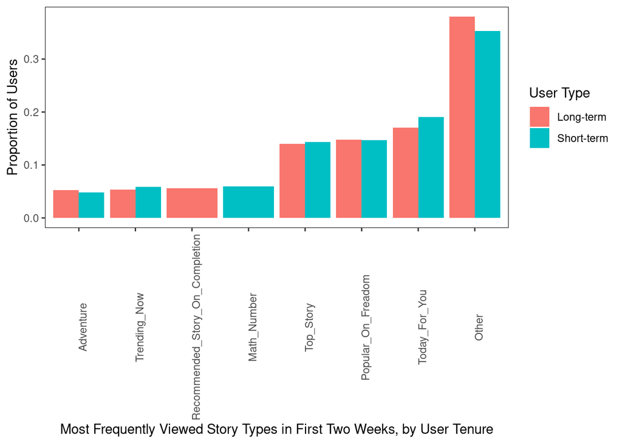

```r
# Get most popular type of story for tenured users in their first two weeks of using the app
tenured_users_frst_two_week_compo_story_types <- tenured_users_compo %>%
  dplyr::filter(days_since_signup < 14) %>%
  select(child_id, section_id) %>%
  group_by(child_id) %>%
  summarize(story_type = mlv(section_id, method='mfv')) %>%
  group_by(story_type) %>%
  summarize(num_users = n())

# get proportion of each story type
tenured_users_frst_two_week_compo_story_types$prop = (tenured_users_frst_two_week_compo_story_types$num_users /
                                                      sum(tenured_users_frst_two_week_compo_story_types$num_users))

# add a tenured user_type column for easier plotting
tenured_users_frst_two_week_compo_story_types$user_type <- 'Long-term'

# get the top 6 story types
top_six_story_types_tenured <- tenured_users_frst_two_week_compo_story_types %>%
  arrange(desc(num_users)) %>%
  head(6)

# get the sum of all other story types
other_story_types_tenured <- tenured_users_frst_two_week_compo_story_types %>%
  arrange(desc(num_users)) %>%
  dplyr::filter(!(story_type %in% top_six_story_types_tenured$story_type)) %>%
  select(num_users,prop) %>%
  summarize(num_users = sum(num_users),
            prop =sum(prop))

# add row to df with top 6 story types with the nymber of "other" story types
top_six_story_types_tenured <- top_six_story_types_tenured %>%
  add_row(story_type = "Other",
          num_users = other_story_types_tenured$num_users,
          prop = other_story_types_tenured$prop,
          user_type = "Long-term")

# Get most popular type of story for short-term users in their first day of using the app
short_term_users_frst_two_week_compo_story_types <- short_term_users_compo %>%
  dplyr::filter(days_since_signup < 14) %>%
  select(child_id, section_id) %>%
  group_by(child_id) %>%
  summarize(story_type = mlv(section_id, method='mfv')) %>%
  group_by(story_type) %>%
  summarize(num_users = n())

# get proportion of each story type
short_term_users_frst_two_week_compo_story_types$prop = (short_term_users_frst_two_week_compo_story_types$num_users /
                                                         sum(short_term_users_frst_two_week_compo_story_types$num_users))

# add a short_term user_type column for easier plotting
short_term_users_frst_two_week_compo_story_types$user_type <- 'Short-term'

# get the top 6 story types
top_six_story_types_short_term <- short_term_users_frst_two_week_compo_story_types %>%
  arrange(desc(num_users)) %>%
  head(6)

# get the sum of all other story types
other_story_types_short_term <- short_term_users_frst_two_week_compo_story_types %>%
  arrange(desc(num_users)) %>%
  dplyr::filter(!(story_type %in% top_six_story_types_short_term$story_type)) %>%
  select(num_users,prop) %>%
  summarize(num_users = sum(num_users),
            prop =sum(prop))

# add row to df with top 6 story types with the nymber of "other" story types
top_six_story_types_short_term <- top_six_story_types_short_term %>%
  add_row(story_type = "Other",
          num_users = other_story_types_short_term$num_users,
          prop = other_story_types_short_term$prop,
          user_type = "Short-term")

# combine the two dataframes together for easier plotting
top_six_story_types_all <- rbind(top_six_story_types_short_term,
                                 top_six_story_types_tenured)

# Plot proportion of short- and long-term users by story type
ggplot(data = top_six_story_types_all,
       aes(fct_reorder(story_type, prop),prop)) +
  geom_bar(stat="identity",
           aes(fill = user_type),
           position=position_dodge()) +
  xlab("Most Frequently Viewed Story Types in First Two Weeks, by User Tenure") +
  ylab("Proportion of Users") +
  labs(fill = "User Type") +
  theme_bw() +
  theme(axis.text.x=element_text(angle = 90, hjust=0.5),
        panel.grid.major = element_blank(),
        panel.grid.minor = element_blank())
```

Lastly, we compare the app section from which short- versus long-term users most frequently choose their stories in the first two weeks in the figure below.

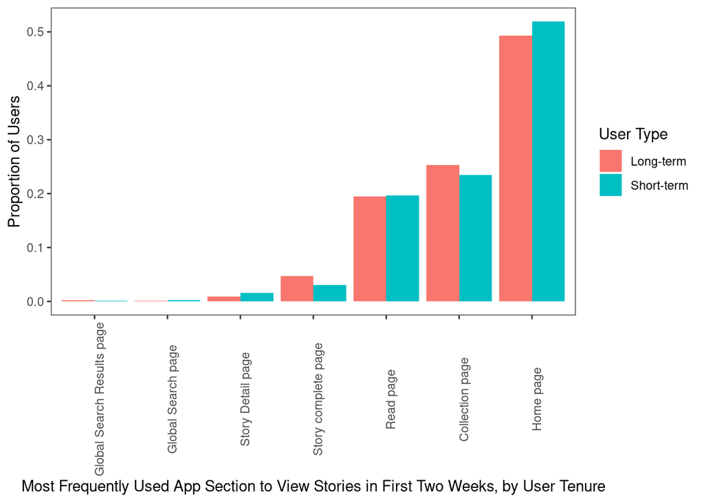

```r
# Get most popular type of app feature for tenured users in their first day of using the app
tenured_users_daily_compo_source_types <- tenured_users_compo %>%
  dplyr::filter(days_since_signup < 14) %>%
  select(child_id, source_page_id) %>%
  group_by(child_id) %>%
  summarize(source_type = mlv(source_page_id, method='mfv')) %>%
  group_by(source_type) %>%
  summarize(num_users = n())

# Get proportion of each app feature type used in the first two weeks in the app for tenured users
tenured_users_daily_compo_source_types$prop = (tenured_users_daily_compo_source_types$num_users /
                                                sum(tenured_users_daily_compo_source_types$num_users))

# Add a tenured user_type column for easier plotting
tenured_users_daily_compo_source_types$user_type <- 'Long-term'

# Get most popular type of app feature for short-term users in their first two weeks of using the app
short_term_users_daily_compo_source_types <- short_term_users_compo %>%
  dplyr::filter(days_since_signup < 14) %>%
  select(child_id, source_page_id) %>%
  group_by(child_id) %>%
  summarize(source_type = mlv(source_page_id, method='mfv')) %>%
  group_by(source_type) %>%
  summarize(num_users = n())

# Get proportion of each app feature type used in the first daily session for short-term users
short_term_users_daily_compo_source_types$prop = (short_term_users_daily_compo_source_types$num_users /
                                                sum(short_term_users_daily_compo_source_types$num_users))

# Add a short_term user_type column for easier plotting
short_term_users_daily_compo_source_types$user_type <- 'Short-term'

# Combine the two dataframes together for easier plotting
all_users_daily_compo_source_types <- rbind(short_term_users_daily_compo_source_types,
                                 tenured_users_daily_compo_source_types)

# Plot proportion of short- and long-term users by app feature type
ggplot(data = all_users_daily_compo_source_types,
       aes(fct_reorder(source_type, prop),prop)) +
  geom_bar(stat="identity",
           aes(fill = user_type),
           position=position_dodge()) +
  xlab("Most Frequently Used App Section to View Stories in First Two Weeks, by User Tenure") +
  ylab("Proportion of Users") +
  labs(fill = "User Type") +
  theme_bw() +
  theme(axis.text.x=element_text(angle = 90, hjust=0.5),
        panel.grid.major = element_blank(),
        panel.grid.minor = element_blank())
```

Each pair of bars in the graph shows the number of short/long-term users who most frequently view stories in their first two weeks through its respective app section. The figure shows few differences again between short- and long-term users in this behavior.

**Exercise** *Repeat the above analysis for either short/long-term users’ first week or first month of usage. Don’t forget to restrict the sample to the appropriate users.*

### First Month

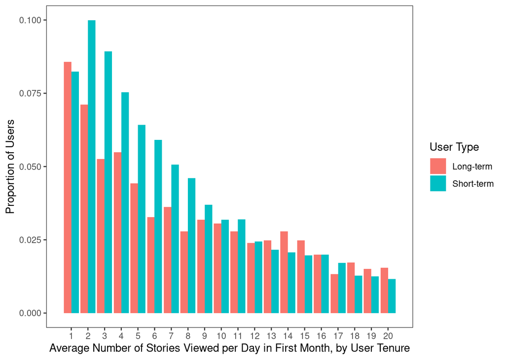

```r
tenured_users_compo_first_month_stories <- tenured_users_compo %>%
  dplyr::filter(days_since_signup < 30) %>%
  group_by(child_id) %>%
  summarize(n_stories_viewed = n_distinct(view_id)) %>%
  group_by(n_stories_viewed) %>%
  summarize(n_users = n())

# Put tenured users with more than 20 stories watched in the first session in the same bin
tenured_users_compo_first_month_stories$n_stories_viewed[tenured_users_compo_first_month_stories$n_stories_viewed> 20] <- 20

# Add a tenure user.type column which will serve as a label when plotting graphs
tenured_users_compo_first_month_stories$user.type <- 'Long-term'

short_term_users_compo_first_month_stories <- short_term_users_compo %>%
  dplyr::filter(days_since_signup < 14) %>%
  group_by(child_id) %>%
  summarize(n_stories_viewed = n_distinct(view_id)) %>%
  group_by(n_stories_viewed) %>%
  summarize(n_users = n())

# Put short-term users with more than 20 stories watched in the first session in the same bin
short_term_users_compo_first_month_stories$n_stories_viewed[short_term_users_compo_first_month_stories$n_stories_viewed >20 ] <- 20

# Add a short_term user.type column which will serve as a label when plotting graphs
short_term_users_compo_first_month_stories$user.type <- 'Short-term'

# Compute proportion of short- and long-term users by number of stories watched in first daily session
tenured_users_compo_first_month_stories$prop <- tenured_users_compo_first_month_stories$n_users / sum(tenured_users_compo_first_month_stories$n_users)

short_term_users_compo_first_month_stories$prop <- short_term_users_compo_first_month_stories$n_users / sum(short_term_users_compo_first_month_stories$n_users)

# Combine the two dataframes for easier plotting
all_users_compo_first_month_stories <- rbind(tenured_users_compo_first_month_stories,
                                       short_term_users_compo_first_month_stories)

# Plot proportion of short- and long-term users by signup date
ggplot(data = all_users_compo_first_month_stories,
       aes(x = n_stories_viewed, y = prop, fill = user.type)) +
  geom_bar(stat="identity", position=position_dodge()) +
  scale_x_continuous(limits = c(0.5,20.5),
                     breaks=seq(1, 20)) +
  xlab("Average Number of Stories Viewed per Day in First Month, by User Tenure") +
  ylab("Proportion of Users") +
  labs(fill = "User Type") +
  theme_bw() +
  theme(axis.text.x=element_text(hjust=0.5),
        panel.grid.major = element_blank(),
        panel.grid.minor = element_blank())
```

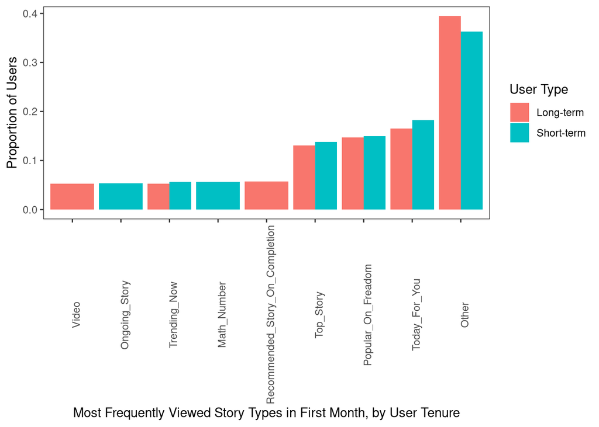

```r
# Get most popular type of story for tenured users in their first month of using the app
tenured_users_frst_month_compo_story_types <- tenured_users_compo %>%
  dplyr::filter(days_since_signup < 30) %>%
  select(child_id, section_id) %>%
  group_by(child_id) %>%
  summarize(story_type = mlv(section_id, method='mfv')) %>%
  group_by(story_type) %>%
  summarize(num_users = n())

# get proportion of each story type
tenured_users_frst_month_compo_story_types$prop = (tenured_users_frst_month_compo_story_types$num_users /
                                                      sum(tenured_users_frst_month_compo_story_types$num_users))

# add a tenured user_type column for easier plotting
tenured_users_frst_month_compo_story_types$user_type <- 'Long-term'

# get the top 6 story types
top_six_story_types_tenured <- tenured_users_frst_month_compo_story_types %>%
  arrange(desc(num_users)) %>%
  head(6)

# get the sum of all other story types
other_story_types_tenured <- tenured_users_frst_month_compo_story_types %>%
  arrange(desc(num_users)) %>%
  dplyr::filter(!(story_type %in% top_six_story_types_tenured$story_type)) %>%
  select(num_users,prop) %>%
  summarize(num_users = sum(num_users),
            prop =sum(prop))

# add row to df with top 6 story types with the nymber of "other" story types
top_six_story_types_tenured <- top_six_story_types_tenured %>%
  add_row(story_type = "Other",
          num_users = other_story_types_tenured$num_users,
          prop = other_story_types_tenured$prop,
          user_type = "Long-term")

# Get most popular type of story for short-term users in their first month of using the app
short_term_users_frst_month_compo_story_types <- short_term_users_compo %>%
  dplyr::filter(days_since_signup < 30) %>%
  select(child_id, section_id) %>%
  group_by(child_id) %>%
  summarize(story_type = mlv(section_id, method='mfv')) %>%
  group_by(story_type) %>%
  summarize(num_users = n())

# get proportion of each story type
short_term_users_frst_month_compo_story_types$prop = (short_term_users_frst_month_compo_story_types$num_users /
                                                         sum(short_term_users_frst_month_compo_story_types$num_users))

# add a short_term user_type column for easier plotting
short_term_users_frst_month_compo_story_types$user_type <- 'Short-term'

# get the top 6 story types
top_six_story_types_short_term <- short_term_users_frst_month_compo_story_types %>%
  arrange(desc(num_users)) %>%
  head(6)

# get the sum of all other story types
other_story_types_short_term <- short_term_users_frst_month_compo_story_types %>%
  arrange(desc(num_users)) %>%
  dplyr::filter(!(story_type %in% top_six_story_types_short_term$story_type)) %>%
  select(num_users,prop) %>%
  summarize(num_users = sum(num_users),
            prop =sum(prop))

# add row to df with top 6 story types with the nymber of "other" story types
top_six_story_types_short_term <- top_six_story_types_short_term %>%
  add_row(story_type = "Other",
          num_users = other_story_types_short_term$num_users,
          prop = other_story_types_short_term$prop,
          user_type = "Short-term")

# combine the two dataframes together for easier plotting
top_six_story_types_all <- rbind(top_six_story_types_short_term,
                                 top_six_story_types_tenured)

# Plot proportion of short- and long-term users by story type
ggplot(data = top_six_story_types_all,
       aes(fct_reorder(story_type, prop),prop)) +
  geom_bar(stat="identity",
           aes(fill = user_type),
           position=position_dodge()) +
  xlab("Most Frequently Viewed Story Types in First Month, by User Tenure") +
  ylab("Proportion of Users") +
  labs(fill = "User Type") +
  theme_bw() +
  theme(axis.text.x=element_text(angle = 90, hjust=0.5),
        panel.grid.major = element_blank(),
        panel.grid.minor = element_blank())
```

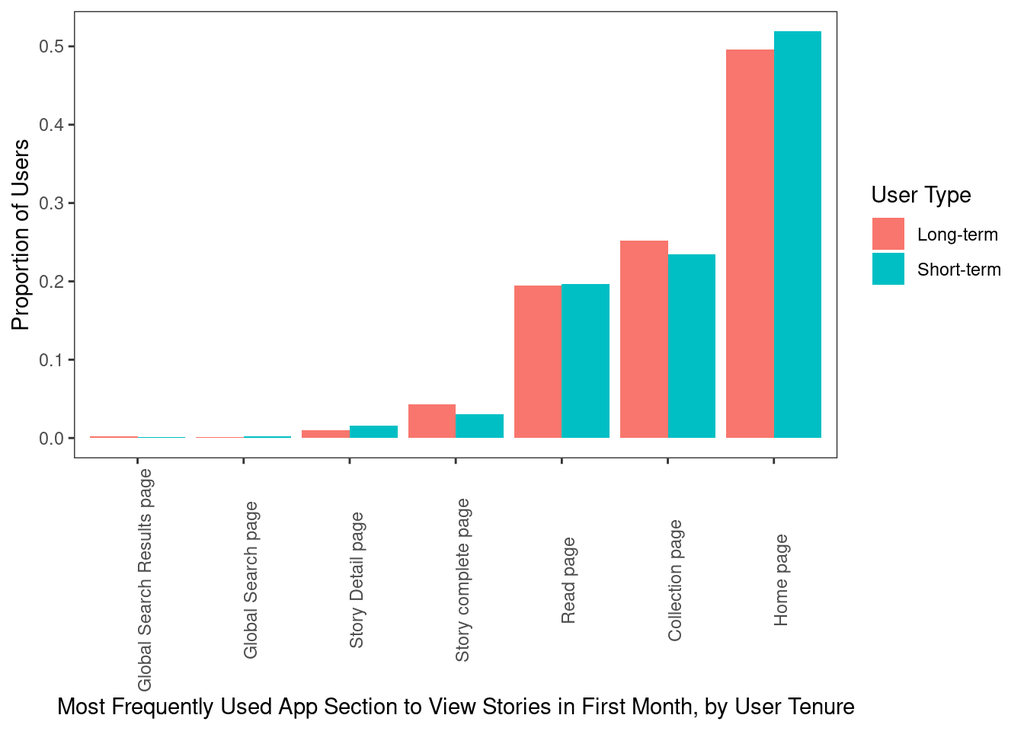

```r
# Get most popular type of app feature for tenured users in their first month of using the app
tenured_users_month_compo_source_types <- tenured_users_compo %>%
  dplyr::filter(days_since_signup < 30) %>%
  select(child_id, source_page_id) %>%
  group_by(child_id) %>%
  summarize(source_type = mlv(source_page_id, method='mfv')) %>%
  group_by(source_type) %>%
  summarize(num_users = n())

# Get proportion of each app feature type used in the first month in the app for tenured users
tenured_users_month_compo_source_types$prop = (tenured_users_month_compo_source_types$num_users /
                                                sum(tenured_users_month_compo_source_types$num_users))

# Add a tenured user_type column for easier plotting
tenured_users_month_compo_source_types$user_type <- 'Long-term'

# Get most popular type of app feature for short-term users in their first month of using the app
short_term_users_month_compo_source_types <- short_term_users_compo %>%
  dplyr::filter(days_since_signup < 14) %>%
  select(child_id, source_page_id) %>%
  group_by(child_id) %>%
  summarize(source_type = mlv(source_page_id, method='mfv')) %>%
  group_by(source_type) %>%
  summarize(num_users = n())

# Get proportion of each app feature type used in the first month session for short-term users
short_term_users_month_compo_source_types$prop = (short_term_users_month_compo_source_types$num_users /
                                                sum(short_term_users_month_compo_source_types$num_users))

# Add a short_term user_type column for easier plotting
short_term_users_month_compo_source_types$user_type <- 'Short-term'

# Combine the two dataframes together for easier plotting
all_users_month_compo_source_types <- rbind(short_term_users_month_compo_source_types,
                                 tenured_users_month_compo_source_types)

# Plot proportion of short- and long-term users by app feature type
ggplot(data = all_users_month_compo_source_types,
       aes(fct_reorder(source_type, prop),prop)) +
  geom_bar(stat="identity",
           aes(fill = user_type),
           position=position_dodge()) +
  xlab("Most Frequently Used App Section to View Stories in First Month, by User Tenure") +
  ylab("Proportion of Users") +
  labs(fill = "User Type") +
  theme_bw() +
  theme(axis.text.x=element_text(angle = 90, hjust=0.5),
        panel.grid.major = element_blank(),
        panel.grid.minor = element_blank())
```